# Psychometric properties validation of HEXACO model in Taiwan sample

此修改版本主要是將原本的題目欄位名稱（例：item46）統一改成只剩下題號（例：46），並藉此有效延伸自訂繪圖函數`loadbar`的適用情境（即`loadbar.facet`）。

# 1 Data Processing & EDA

## 1.1 Import and join dataset

- 把人口變項的資料與題目的資料合併後共有521位研究參與者。
- 扣除出生年月日亂填答者，共剩519位。

```r
library(dplyr)
item = read.csv("user_personality.csv")
demo = read.csv("user_demographics.csv")
rawdf = inner_join(demo, item, by = "id")
rawdf = rawdf[,-c(2, 3, 12)]

factor_cols = c("gender", "marr", "location", "edu", "industry", "occupation", "income")
rawdf[factor_cols] = lapply(rawdf[factor_cols], factor)

# Drop 2 sample due to their bday = 2016 or 2017 (too young!!)
rawdf = subset(rawdf, rawdf$bday != "2016-09-15"&rawdf$bday != "2017-01-18")

# Create "age" variable (reference year = 2017 or 106)
rawdf$age = as.integer(substr(rawdf$bday, 1, 4))
rawdf$age = ifelse(rawdf$age < 100, 106 - rawdf$age, 2017 - rawdf$age)

# Change the col order of rawdf
library(data.table)
setcolorder(rawdf, c("id","age", colnames(rawdf)[-c(1, 70)]))

# Delete "item" in colnames
colnames(rawdf) = c(colnames(rawdf)[1:10], as.character(1:60))
```

## 1.2 Item information: dimension, reverse items and statements

[Reference](http://hexaco.org/downloads/ScoringKeys_60.pdf)

```r
re_item = c(-1,1,1,1,1,1,1,1,-1,-1, 1,-1,1,-1,-1,1,1,1,-1,-1,
            -1,1,1,-1,1,-1,1,-1,1,-1, -1,-1,1,1,-1,1,1,1,1,1,
            -1,-1,1,-1,1,-1,1,-1,-1,1, 1,-1,-1,1,-1,-1,-1,1,-1,-1)
maindim = rep(c("Openness to Experience","Conscientiousness","Agreeableness","Extraversion","Emotionality","Honesty-Humility"), 10)
subdim = c(rep(c("Aesthetic Appreciation","Organization","Forgiveness","Social Self-Esteem","Fearfulness","Sincerity","Inquisitiveness","Diligence","Gentleness","Social Boldness","Anxiety","Fairness","Creativity","Perfectionism","Flexibility","Sociability","Dependence","Greed-Avoidance","Unconventionality","Prudence","Patience","Liveliness","Sentimentality","Modesty"),2), c("Creativity","Perfectionism","Gentleness","Social Self-Esteem","Fearfulness","Sincerity","Unconventionality","Prudence","Flexibility","Social Boldness","Sentimentality","Fairness"))
statement = c("我覺得參觀美術館很無聊。",
              "我會在事前計畫和組織要做的事，避免最後一分鐘手忙腳亂。",
              "我很少有怨恨，即使面對那些對我很壞的人。",
              "整體而言我對自己還算滿意。",
              "如果我必須在惡劣氣候之下出外，我會感到害怕。",
              "即使我相信用巴結的方式可以得到獎勵，我也不會做。",
              "我喜歡去學習外國的歷史和政治。",
              "我通常把自己逼得很緊，以求達到目標。",
              "有時候其他人告訴我對別人太挑剔。",
              "在團體討論中，我很少表達自己的意見。",
              "我會為一些小事而有些焦躁不安。",
              "如果我知道自己永遠不會被抓，我也想要去偷一百萬。",
              "我喜歡從事藝術創作，例如，寫小說、寫歌、繪畫。",
              "做事時, 我不太注意小細節。",
              "有時候其他人認為我太頑固。",
              "我喜愛需要主動與人互動的工作多於只需獨自一人進行的工作。",
              "當我遭遇到痛苦的經驗時，我需要其他人的安慰。",
              "對我來說，擁有很多金錢不是特別重要。",
              "我認為聽取極端意見是在浪費時間。",
              "我以當時的感受來作決定，而不會仔細思考。",
              "別人認為我是一個很暴躁的人。",
              "大多數日子裡, 我都感到愉快和樂觀。",
              "看到別人哭時，我也會想哭。",
              "我認為我比一般人有資格得到更多的尊重。",
              "如果我有機會, 我會想去參加古典音樂會。",
              "在工作上, 我有時候會因為沒有好的計畫而遇到困難。",
              "面對那些對我很壞的人，我的態度是「原諒與忘記」。",
              "我覺得自己是個不受歡迎的人。",
              "面對可能使身體受傷的險境, 我會很害怕。",
              "如果我想從某人手中得到一些東西, 即使那個人講的笑話再不好笑，我也會哈哈大笑。",
              "翻閱百科全書這件事，我從沒真正喜歡過。",
              "我只做每天應做的最少工作量。",
              "我采寬厚的態度去評論他人。",
              "在社交場合裡, 我通常都是那個先主動的人。",
              "比起大多數人，我擔心的事少了很多。",
              "即使很有價值，我也絕不會接受賄賂。",
              "別人經常說我有很好的想像力。",
              "即使要花很多的時間，在工作上，我還是力求精確。",
              "當別人不同意我的時候, 我通常能讓自己的意見保持相當的彈性。",
              "通常我到新環境做的第一件事就是交新朋友。",
              "我可以處理困難的處境而不需要任何人的情感支援。",
              "如果有機會可以擁有昂貴的奢侈品，我會獲得很大的快樂。",
              "我喜歡那些對事情有獨特見解的人。",
              "我因採取行動前沒有仔細思考而犯下很多錯誤。",
              "大多數的人比我容易生氣。",
              "大多數人都比平常的我要樂觀和有活力。",
              "當親近的人要離開一段很長的時間，我會有很深的感傷。",
              "我想讓別人知道我是個地位高的重要人物。",
              "我不認為自己是那種有藝術天份或創意的人。",
              "別人常說我是個完美主義者。",
              "即使當別人犯很多的錯誤, 我也很少說難聽的話。",
              "我有時會覺得自已一文不值。",
              "即使在非常危急的情況, 我不會感覺到驚慌。",
              "我不會為了讓某人幫我做事而假裝喜歡那個人。",
              "我發覺討論哲學很乏味。",
              "我喜歡想到什麼就做什麼，不喜歡按計劃行事。",
              "當別人說我錯了，我第一個反應就是跟他們爭辯。",
              "在團體中，我常是那個代表團體說話的人。",
              "即使在大多數人變得很感傷的情境中，我仍可不動情感。",
              "我會禁不住誘惑用偽鈔，如果我確定絕不會被抓到。")

item_info = data.frame(maindim, subdim, statement, re_item)
row.names(item_info) = colnames(rawdf)[11:70]
```

## 1.3 EDA (demographics)

```r
library(psych)
eda_demo = lapply(rawdf[factor_cols], table)
print(eda_demo)
```

```
## $gender
##
##   1   2   3
## 234 282   3
##
## $marr
##
##   1   2   3   4   5
## 248 169  92   2   8
##
## $location
##
##   1   2   3   4   5   6   7   8   9  10  11  12  13  14  15  16  17  18
## 125 134   7  44  20   7   7   4  52   2  19   3   2   3  34  40   5   7
##  19  20
##   3   1
##
## $edu
##
##   1   2   3   4   5   7
## 178 296  26  17   1   1
##
## $industry
##
##   1   2   3   4   5   6   7   8   9  10  11  12  13  14  15  16
##   3  16   3  10  34  10  46  20  88  48  32  15   8  39 129  18
##
## $occupation
##
##   1   2   3   4   5   6   9  10  11  12  13
##   6 141  50  40  61   3  12   3  17 158  28
##
## $income
##
##   1   2   3   4   5   6   7   8
##  68  87 189 111  30   4   8  22
```

```r
describe(rawdf$age)
```

```
##    vars   n  mean   sd median trimmed  mad min max range skew kurtosis
## X1    1 519 29.99 7.63     28   28.91 5.93  16  70    54 1.73     4.06
##      se
## X1 0.34
```

## 1.4 EDA (items, before reverse scoring)

1. Missing values

```r
table(is.na(rawdf)) # No missing value
```

```
##
## FALSE
## 36330
```

2. Statistics
- [Joanes, D. N. & Gill, C. A. (1998)](http://onlinelibrary.wiley.com/doi/10.1111/1467-9884.00122/abstract)
- Skewness: $b_1 = \frac{m_3}{s^3}= (\frac{n-1}{n})^{\frac{3}{2}} \frac{m_3}{m_2^{3/2}}$
- Kurtosis:$b_2 = \frac{m_4}{s^4}-3 = (\frac{n-1}{n})^2 \frac{m_4}{m_2^2}-3$
- Where $m_r = \frac{1}{n}\sum_{i=1}^{n}{(x_i - \bar{x})^r}$ and $s^2 = \frac{1}{n-1}\sum_{i=1}^{n}{(x_i - \bar{x})^2}$.

```r
item_stat = describe(rawdf[,11:70])

#write.csv(round(item stat,4)[,-c(1,2,8:10,13)], "item_stat_before reversed.csv")
```

3. Plots

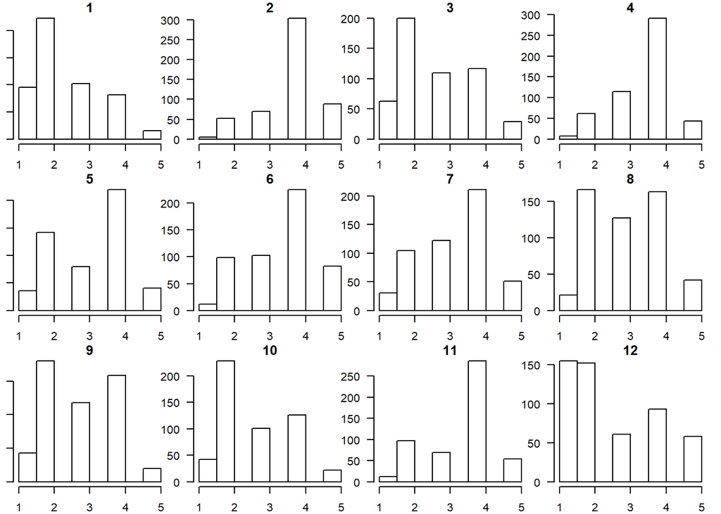

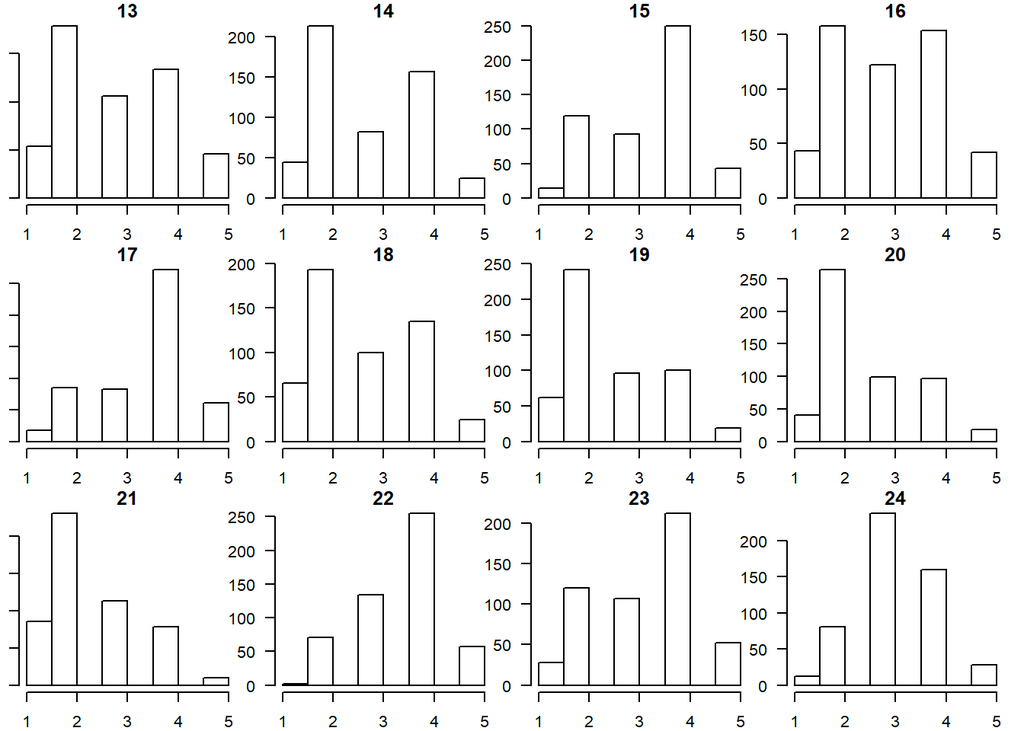

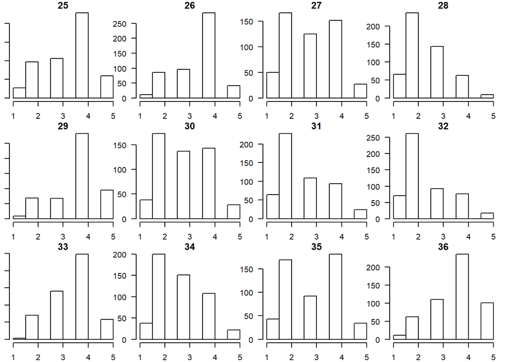

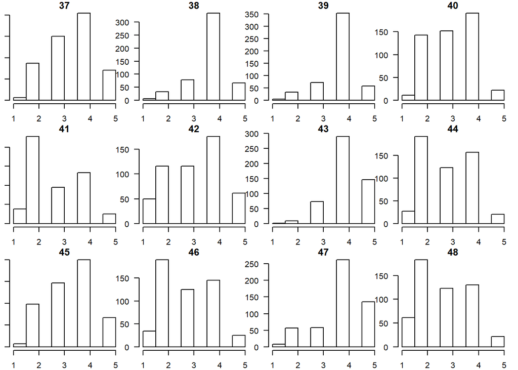

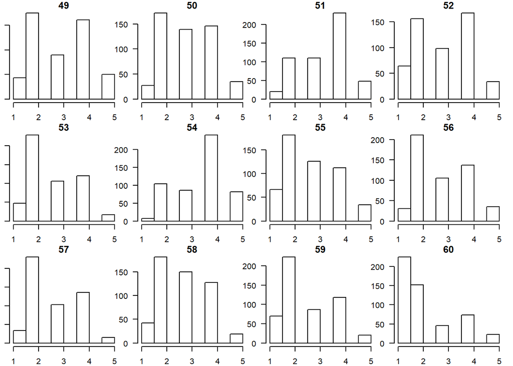

```r
dfplot <- function(data.frame){
  df <- data.frame
  ln <- length(names(data.frame))
  for(i in 1:ln){
    mname <- substitute(df[, i])
      if(is.factor(df[, i])){
        #png(paste("vardist_", i, ".png", sep = ""))
        plot(df[, i], main = names(df)[i], las = 1)
        #dev.off()
        }
      else if(is.character(df[, i])){
        #png(paste("vardist_", i, ".png", sep = ""))
        plot(as.factor(df[, i]), main = names(df)[i], las = 1)
        #dev.off()
        }
      else{
        #png(paste("vardist_", i, ".png", sep = ""))
        hist(df[, i], main = names(df)[i], las = 1)
        #dev.off()
        }
    }
}
par(mfrow=c(3,4),mar=c(2,1,1,1))
dfplot(rawdf[,11:70])
```

4. Another visualization

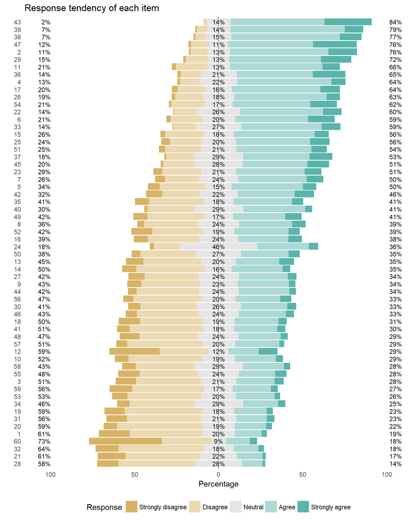

```r
library(likert)
item_vis = rawdf[,11:70]

item_vis[] = lapply(item_vis, factor, levels=1:5,
                    labels = c("Strongly disagree", "Disagree", "Neutral", "Agree", "Strongly agree"), ordered = T)

#names(item_vis) = item_info$statement


item_vis_l = likert(item_vis)
#summary(item_vis_l)


item_dist = plot(item_vis_l, type="bar") + # type = "density" or "heat"
  labs(title = "Response tendency of each item") +
  theme(panel.background = element_rect(fill = "transparent", colour = NA),
        plot.background = element_rect(fill = "transparent", colour = NA))
print(item_dist)
```

## 1.5 Reverse scoring & Correlation matrix

- `rawdf` = raw data (with demographics information)
- `re_rawdf` = raw data after reverse scoring

```r
re_rawdf = reverse.code(item_info$re_item, rawdf[,c(11:70)], mini = 1, maxi = 5)

item_stat_r = cbind(dimension = item_info$maindim, facet = item_info$subdim, round(describe(re_rawdf), 4)) %>%
  arrange(dimension, facet)
colnames(item_stat_r)[3] = "item"

# write.csv(item_stat_r[,-c(4,9:12,15)], "item stat_reversed.csv")
knitr::kable(item_stat_r, caption = 'Descriptive statistics of all items (n = 519, 5-point scale)')
```

Descriptive statistics of all items (n = 519, 5-point scale)

| dimension | facet | item | n | mean | sd | median | trimmed | mad | min | max | range | skew | kurtosis | se |
| --- | --- | --- | --- | --- | --- | --- | --- | --- | --- | --- | --- | --- | --- | --- |
| Agreeableness | Flexibility | 15 | 519 | 2.6358 | 1.0098 | 2 | 2.6163 | 1.4826 | 1 | 5 | 4 | 0.4474 | -0.7763 | 0.0443 |
| Agreeableness | Flexibility | 39 | 519 | 3.8208 | 0.7409 | 4 | 3.8777 | 0.0000 | 1 | 5 | 4 | -1.1805 | 2.1868 | 0.0325 |
| Agreeableness | Flexibility | 57 | 519 | 3.2563 | 1.0105 | 4 | 3.2734 | 1.4826 | 1 | 5 | 4 | -0.3144 | -0.9432 | 0.0444 |
| Agreeableness | Forgiveness | 3 | 519 | 2.7091 | 1.1125 | 2 | 2.6906 | 1.4826 | 1 | 5 | 4 | 0.3041 | -0.8455 | 0.0488 |
| Agreeableness | Forgiveness | 27 | 519 | 2.8825 | 1.0921 | 3 | 2.9089 | 1.4826 | 1 | 5 | 4 | 0.0291 | -0.9590 | 0.0479 |
| Agreeableness | Gentleness | 9 | 519 | 3.1310 | 1.0591 | 3 | 3.1079 | 1.4826 | 1 | 5 | 4 | -0.0382 | -1.0121 | 0.0465 |
| Agreeableness | Gentleness | 33 | 519 | 3.5549 | 0.8811 | 4 | 3.5755 | 1.4826 | 1 | 5 | 4 | -0.3949 | -0.4016 | 0.0387 |
| Agreeableness | Gentleness | 51 | 519 | 3.3410 | 1.0329 | 4 | 3.3573 | 1.4826 | 1 | 5 | 4 | -0.4214 | -0.6891 | 0.0453 |
| Agreeableness | Patience | 21 | 519 | 3.5857 | 0.9980 | 4 | 3.6307 | 1.4826 | 1 | 5 | 4 | -0.4864 | -0.4543 | 0.0438 |
| Agreeableness | Patience | 45 | 519 | 3.4277 | 0.9815 | 4 | 3.4269 | 1.4826 | 1 | 5 | 4 | -0.2017 | -0.7451 | 0.0431 |
| Conscientiousness | Diligence | 8 | 519 | 3.0751 | 1.0564 | 3 | 3.0432 | 1.4826 | 1 | 5 | 4 | 0.0563 | -0.9778 | 0.0464 |
| Conscientiousness | Diligence | 32 | 519 | 3.5665 | 1.0053 | 4 | 3.6235 | 0.0000 | 1 | 5 | 4 | -0.6940 | -0.1436 | 0.0441 |
| Conscientiousness | Organization | 2 | 519 | 3.8054 | 0.8692 | 4 | 3.8921 | 0.0000 | 1 | 5 | 4 | -0.8823 | 0.6163 | 0.0382 |
| Conscientiousness | Organization | 26 | 519 | 2.5010 | 0.9318 | 2 | 2.4508 | 0.0000 | 1 | 5 | 4 | 0.7117 | -0.2005 | 0.0409 |
| Conscientiousness | Perfectionism | 14 | 519 | 3.1869 | 1.0966 | 3 | 3.1847 | 1.4826 | 1 | 5 | 4 | -0.1982 | -1.0981 | 0.0481 |
| Conscientiousness | Perfectionism | 38 | 519 | 3.8189 | 0.7748 | 4 | 3.8801 | 0.0000 | 1 | 5 | 4 | -1.0685 | 1.7867 | 0.0340 |
| Conscientiousness | Perfectionism | 50 | 519 | 2.9807 | 1.0451 | 3 | 2.9568 | 1.4826 | 1 | 5 | 4 | 0.1193 | -0.8777 | 0.0459 |
| Conscientiousness | Prudence | 20 | 519 | 3.4104 | 0.9918 | 4 | 3.4556 | 0.0000 | 1 | 5 | 4 | -0.6167 | -0.4358 | 0.0435 |
| Conscientiousness | Prudence | 44 | 519 | 3.0944 | 1.0138 | 3 | 3.1007 | 1.4826 | 1 | 5 | 4 | -0.1114 | -1.0021 | 0.0445 |
| Conscientiousness | Prudence | 56 | 519 | 3.1272 | 1.0795 | 3 | 3.1679 | 1.4826 | 1 | 5 | 4 | -0.2900 | -0.9543 | 0.0474 |
| Emotionality | Anxiety | 11 | 519 | 3.5222 | 0.9918 | 4 | 3.5588 | 0.0000 | 1 | 5 | 4 | -0.7012 | -0.3623 | 0.0435 |
| Emotionality | Anxiety | 35 | 519 | 3.0116 | 1.1270 | 3 | 2.9928 | 1.4826 | 1 | 5 | 4 | 0.0500 | -1.1132 | 0.0495 |
| Emotionality | Dependence | 17 | 519 | 3.5260 | 1.0109 | 4 | 3.5755 | 0.0000 | 1 | 5 | 4 | -0.7086 | -0.2296 | 0.0444 |
| Emotionality | Dependence | 41 | 519 | 3.2331 | 1.0625 | 4 | 3.2590 | 1.4826 | 1 | 5 | 4 | -0.3479 | -0.9156 | 0.0466 |
| Emotionality | Fearfulness | 5 | 519 | 3.1696 | 1.1246 | 4 | 3.1990 | 1.4826 | 1 | 5 | 4 | -0.2950 | -1.0383 | 0.0494 |
| Emotionality | Fearfulness | 29 | 519 | 3.7437 | 0.9535 | 4 | 3.8225 | 0.0000 | 1 | 5 | 4 | -0.8052 | 0.1191 | 0.0419 |
| Emotionality | Fearfulness | 53 | 519 | 3.3256 | 1.0304 | 4 | 3.3333 | 1.4826 | 1 | 5 | 4 | -0.3631 | -0.8022 | 0.0452 |
| Emotionality | Sentimentality | 23 | 519 | 3.2697 | 1.0889 | 4 | 3.2806 | 1.4826 | 1 | 5 | 4 | -0.3331 | -0.8322 | 0.0478 |
| Emotionality | Sentimentality | 47 | 519 | 3.8863 | 0.9649 | 4 | 4.0000 | 0.0000 | 1 | 5 | 4 | -0.9045 | 0.3512 | 0.0424 |
| Emotionality | Sentimentality | 59 | 519 | 3.3911 | 1.0990 | 4 | 3.4149 | 1.4826 | 1 | 5 | 4 | -0.3893 | -0.8466 | 0.0482 |
| Extraversion | Liveliness | 22 | 519 | 3.5665 | 0.8737 | 4 | 3.5875 | 1.4826 | 1 | 5 | 4 | -0.4113 | -0.4286 | 0.0384 |
| Extraversion | Liveliness | 46 | 519 | 3.1214 | 1.0429 | 3 | 3.1295 | 1.4826 | 1 | 5 | 4 | -0.1513 | -0.9273 | 0.0458 |
| Extraversion | Sociability | 16 | 519 | 2.9884 | 1.1219 | 3 | 2.9880 | 1.4826 | 1 | 5 | 4 | 0.0145 | -0.9662 | 0.0492 |
| Extraversion | Sociability | 40 | 519 | 3.1349 | 0.9388 | 3 | 3.1415 | 1.4826 | 1 | 5 | 4 | -0.1164 | -0.9191 | 0.0412 |
| Extraversion | Social Boldness | 10 | 519 | 3.2736 | 1.0500 | 4 | 3.2926 | 1.4826 | 1 | 5 | 4 | -0.3619 | -0.8501 | 0.0461 |
| Extraversion | Social Boldness | 34 | 519 | 2.7611 | 1.0004 | 3 | 2.7410 | 1.4826 | 1 | 5 | 4 | 0.3053 | -0.6135 | 0.0439 |
| Extraversion | Social Boldness | 58 | 519 | 2.8073 | 1.0141 | 3 | 2.8153 | 1.4826 | 1 | 5 | 4 | 0.1361 | -0.7750 | 0.0445 |
| Extraversion | Social Self-Esteem | 4 | 519 | 3.5761 | 0.8618 | 4 | 3.6331 | 0.0000 | 1 | 5 | 4 | -0.7682 | 0.2612 | 0.0378 |
| Extraversion | Social Self-Esteem | 28 | 519 | 3.5549 | 0.9218 | 4 | 3.5899 | 1.4826 | 1 | 5 | 4 | -0.4710 | -0.1649 | 0.0405 |
| Extraversion | Social Self-Esteem | 52 | 519 | 3.0944 | 1.1711 | 3 | 3.0767 | 1.4826 | 1 | 5 | 4 | 0.0328 | -1.1122 | 0.0514 |
| Honesty-Humility | Fairness | 12 | 519 | 3.4875 | 1.3710 | 4 | 3.6067 | 1.4826 | 1 | 5 | 4 | -0.4853 | -1.0908 | 0.0602 |
| Honesty-Humility | Fairness | 36 | 519 | 3.6802 | 0.9873 | 4 | 3.7506 | 1.4826 | 1 | 5 | 4 | -0.6018 | -0.1726 | 0.0433 |
| Honesty-Humility | Fairness | 60 | 519 | 3.9306 | 1.2172 | 4 | 4.0911 | 1.4826 | 1 | 5 | 4 | -0.9253 | -0.3323 | 0.0534 |
| Honesty-Humility | Greed-Avoidance | 18 | 519 | 2.7303 | 1.1238 | 3 | 2.7266 | 1.4826 | 1 | 5 | 4 | 0.2085 | -0.9932 | 0.0493 |
| Honesty-Humility | Greed-Avoidance | 42 | 519 | 2.8420 | 1.1815 | 3 | 2.8058 | 1.4826 | 1 | 5 | 4 | 0.2299 | -0.9394 | 0.0519 |
| Honesty-Humility | Modesty | 24 | 519 | 2.7861 | 0.8534 | 3 | 2.7722 | 1.4826 | 1 | 5 | 4 | 0.1244 | -0.0551 | 0.0375 |
| Honesty-Humility | Modesty | 48 | 519 | 3.2524 | 1.0869 | 3 | 3.2446 | 1.4826 | 1 | 5 | 4 | -0.1601 | -0.9115 | 0.0477 |
| Honesty-Humility | Sincerity | 6 | 519 | 3.5145 | 1.0413 | 4 | 3.5468 | 1.4826 | 1 | 5 | 4 | -0.4275 | -0.6821 | 0.0457 |
| Honesty-Humility | Sincerity | 30 | 519 | 3.0963 | 1.0538 | 3 | 3.0959 | 1.4826 | 1 | 5 | 4 | -0.0934 | -0.8719 | 0.0463 |
| Honesty-Humility | Sincerity | 54 | 519 | 3.5511 | 1.0233 | 4 | 3.5803 | 1.4826 | 1 | 5 | 4 | -0.4451 | -0.7550 | 0.0449 |
| Openness to Experience | Aesthetic Appreciation | 1 | 519 | 3.5800 | 1.0567 | 4 | 3.6379 | 1.4826 | 1 | 5 | 4 | -0.5334 | -0.4833 | 0.0464 |
| Openness to Experience | Aesthetic Appreciation | 25 | 519 | 3.3815 | 1.0749 | 4 | 3.4173 | 1.4826 | 1 | 5 | 4 | -0.4930 | -0.5904 | 0.0472 |
| Openness to Experience | Creativity | 13 | 519 | 2.8825 | 1.1673 | 3 | 2.8657 | 1.4826 | 1 | 5 | 4 | 0.1705 | -1.0070 | 0.0512 |
| Openness to Experience | Creativity | 37 | 519 | 3.4778 | 0.9641 | 4 | 3.4868 | 1.4826 | 1 | 5 | 4 | -0.2341 | -0.6688 | 0.0423 |
| Openness to Experience | Creativity | 49 | 519 | 3.0000 | 1.1691 | 3 | 3.0168 | 1.4826 | 1 | 5 | 4 | -0.0506 | -1.1187 | 0.0513 |
| Openness to Experience | Inquisitiveness | 7 | 519 | 3.2832 | 1.0775 | 4 | 3.3046 | 1.4826 | 1 | 5 | 4 | -0.3940 | -0.6783 | 0.0473 |
| Openness to Experience | Inquisitiveness | 31 | 519 | 3.4123 | 1.0634 | 4 | 3.4484 | 1.4826 | 1 | 5 | 4 | -0.4919 | -0.5534 | 0.0467 |
| Openness to Experience | Unconventionality | 19 | 519 | 3.4393 | 1.0452 | 4 | 3.4700 | 1.4826 | 1 | 5 | 4 | -0.5126 | -0.5824 | 0.0459 |
| Openness to Experience | Unconventionality | 43 | 519 | 4.1002 | 0.7068 | 4 | 4.1511 | 0.0000 | 1 | 5 | 4 | -0.5691 | 0.6295 | 0.0310 |
| Openness to Experience | Unconventionality | 55 | 519 | 3.2563 | 1.1278 | 3 | 3.2782 | 1.4826 | 1 | 5 | 4 | -0.2556 | -0.8254 | 0.0495 |

```r
range(item_stat_r$mean)
```

```
## [1] 2.5010 4.1002
```

```r
range(item_stat_r$median)
```

```
## [1] 2 4
```

```r
range(item_stat_r$sd)
```

```
## [1] 0.7068 1.3710
```

```r
range(item_stat_r$skew)
```

```
## [1] -1.1805  0.7117
```

```r
range(item_stat_r$kurtosis)
```

```
## [1] -1.1187  2.1868
```

```r
# Can try different types of correlation: Pearson's r, Spearman, or polychoric

# This code (calculating polychoric cor) takes time (about 50 sec?)
item_poly = polychoric(re_rawdf, ML = F, std.err = F)
```

```
## 972 cells were adjusted for 0 values using the correction for continuity. Examine your data carefully.
```

```r
#print(round(item_poly$rho, 2))
# 972 cells were adjusted for 0 values using the correction for continuity (add 0.5)

# write.csv(item_poly$rho, "cor matrix_poly.csv")

subject = nrow(re_rawdf)
n_var = ncol(re_rawdf)
```

# 2 Item Analysis

## 2.1 六大向度計分 (`dimscore`)

```r
#scoring key to calculate the scale scores for each of our 5 scal
itemonly = rawdf[,11:70]

item.keys.list = list(Agree = c(3, -9, -15, -21, 27, 33, 39, 45, 51, -57),
                      Consc = c(2, 8, -14, -20, -26, -32, 38, -44, 50, -56),
                      Emo = c(5, 11, 17, 23, 29, -35, -41, 47, -53, -59),
                      Extra = c(4, -10, 16, 22, -28, 34, 40, -46, -52, 58),
                      HH = c(6, -12, 18, -24, -30, 36, -42, -48, 54, -60),
                      Open = c(-1, 7, 13, -19, 25, -31, 37, 43, -49, -55))
item.keys = make.keys(itemonly, item.keys.list)

item.scored = scoreItems(keys = item.keys, items = itemonly, totals = FALSE,
                         missing = FALSE, min = 1, max = 5, digits = 3)

item.scored$missing # How many items were not answered for each scale
```

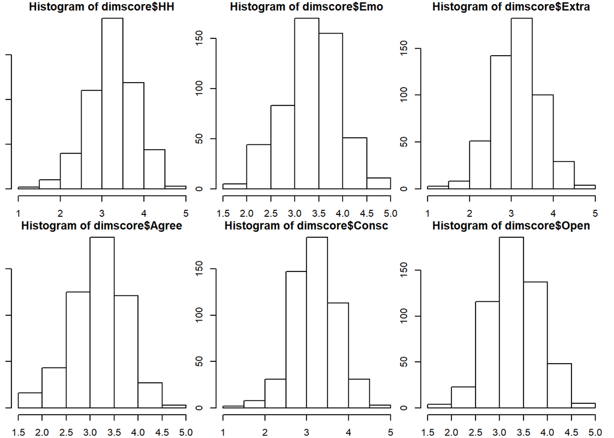

```r
# item.scored$scores # Each subject's average score (totals = F) on 6 dims
dimscore = cbind(as.data.frame(item.scored$scores), rawdf[, 2:10])

par(mfrow=c(2,3),mar=c(2,1,1,1))
hist(dimscore$HH); hist(dimscore$Emo); hist(dimscore$Extra)
hist(dimscore$Agree); hist(dimscore$Consc); hist(dimscore$Open)
```

```r
knitr::kable(as.data.frame(round(describeBy(dimscore[1:6]),4))[,-1], caption = 'Descriptive statistics of score in each scale')
```

Descriptive statistics of score in each scale

|  | n | mean | sd | median | trimmed | mad | min | max | range | skew | kurtosis | se |
| --- | --- | --- | --- | --- | --- | --- | --- | --- | --- | --- | --- | --- |
| Agree | 519 | 3.2345 | 0.5563 | 3.3 | 3.2432 | 0.5930 | 1.7 | 4.8 | 3.1 | -0.1185 | 0.0120 | 0.0244 |
| Consc | 519 | 3.2566 | 0.5229 | 3.3 | 3.2628 | 0.4448 | 1.2 | 4.8 | 3.6 | -0.2044 | 0.5404 | 0.0230 |
| Emo | 519 | 3.4079 | 0.5752 | 3.4 | 3.4281 | 0.5930 | 1.6 | 5.0 | 3.4 | -0.2527 | 0.0039 | 0.0252 |
| Extra | 519 | 3.1879 | 0.5703 | 3.2 | 3.1885 | 0.5930 | 1.2 | 4.8 | 3.6 | -0.0568 | 0.1241 | 0.0250 |
| HH | 519 | 3.2871 | 0.5764 | 3.3 | 3.3022 | 0.5930 | 1.2 | 4.7 | 3.5 | -0.3005 | 0.2657 | 0.0253 |
| Open | 519 | 3.3813 | 0.5354 | 3.4 | 3.3767 | 0.5930 | 1.6 | 4.9 | 3.3 | 0.0123 | 0.0211 | 0.0235 |

```r
#write.csv(round(describeBy(dimscore[1:6]),4)[,-1], "dim score.csv")

stat_gender = describeBy(dimscore[1:6], dimscore$gender)
print(stat_gender)
```

```
##
##  Descriptive statistics by group
## group: 1
##       vars   n mean   sd median trimmed  mad min max range  skew kurtosis
## Agree    1 234 3.26 0.55   3.35    3.28 0.52 1.8 4.5   2.7 -0.33    -0.19
## Consc    2 234 3.28 0.52   3.30    3.29 0.44 1.2 4.7   3.5 -0.39     1.19
## Emo      3 234 3.18 0.54   3.20    3.18 0.44 1.7 4.6   2.9 -0.08    -0.26
## Extra    4 234 3.22 0.55   3.30    3.23 0.59 1.2 4.8   3.6 -0.29     0.64
## HH       5 234 3.20 0.59   3.20    3.22 0.59 1.2 4.5   3.3 -0.38     0.24
## Open     6 234 3.34 0.51   3.40    3.35 0.44 1.6 4.8   3.2 -0.21     0.47
##         se
## Agree 0.04
## Consc 0.03
## Emo   0.04
## Extra 0.04
## HH    0.04
## Open  0.03
## --------------------------------------------------------
## group: 2
##       vars   n mean   sd median trimmed  mad min max range  skew kurtosis
## Agree    1 282 3.21 0.56    3.2    3.21 0.44 1.7 4.8   3.1  0.04     0.19
## Consc    2 282 3.24 0.52    3.3    3.24 0.44 1.7 4.8   3.1 -0.05     0.07
## Emo      3 282 3.60 0.53    3.6    3.62 0.44 1.6 5.0   3.4 -0.46     0.88
## Extra    4 282 3.17 0.58    3.2    3.16 0.59 1.4 4.7   3.3  0.14    -0.21
## HH       5 282 3.35 0.55    3.4    3.36 0.59 1.7 4.7   3.0 -0.17     0.11
## Open     6 282 3.41 0.55    3.4    3.40 0.59 2.1 4.9   2.8  0.13    -0.36
##         se
## Agree 0.03
## Consc 0.03
## Emo   0.03
## Extra 0.03
## HH    0.03
## Open  0.03
## --------------------------------------------------------
## group: 3
##       vars n mean   sd median trimmed  mad min max range  skew kurtosis
## Agree    1 3 3.67 0.64    3.3    3.67 0.00 3.3 4.4   1.1  0.38    -2.33
## Consc    2 3 2.90 0.62    2.7    2.90 0.44 2.4 3.6   1.2  0.29    -2.33
## Emo      3 3 3.30 0.78    2.9    3.30 0.15 2.8 4.2   1.4  0.38    -2.33
## Extra    4 3 2.60 0.69    3.0    2.60 0.00 1.8 3.0   1.2 -0.38    -2.33
## HH       5 3 3.70 0.46    3.8    3.70 0.44 3.2 4.1   0.9 -0.21    -2.33
## Open     6 3 3.60 0.75    3.5    3.60 0.89 2.9 4.4   1.5  0.13    -2.33
##         se
## Agree 0.37
## Consc 0.36
## Emo   0.45
## Extra 0.40
## HH    0.26
## Open  0.44
```

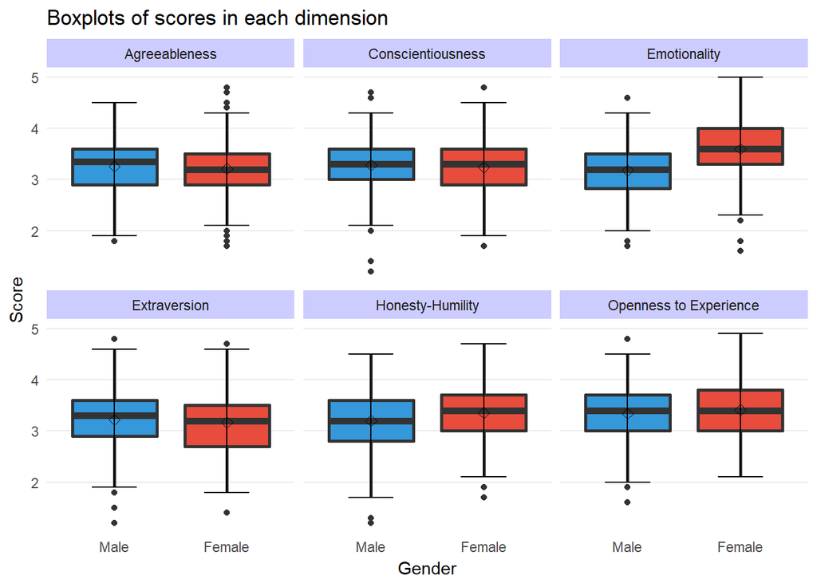

```r
#write.csv(describeBy(dimscore[1:6], dimscore$gender)$`1`, "dim score_male.csv")
#write.csv(describeBy(dimscore[1:6], dimscore$gender)$`2`, "dim score_female.csv")

### Boxplots ###
library(ggplot2); library(reshape2)

dimscore_l = melt(dimscore, id.vars = colnames(dimscore)[7:ncol(dimscore)],
                  measure.vars = colnames(dimscore)[1:6],
                  variable.name = "Dimension",
                  value.name = "Score")

scale.labels = c(Agree = "Agreeableness", Consc = "Conscientiousness", Emo = "Emotionality", Extra = "Extraversion", HH = "Honesty-Humility", Open = "Openness to Experience")

ggplot(filter(dimscore_l, gender != "3"), aes(x = gender, y = Score, fill = gender)) +
  geom_boxplot(aes(),size = 1) +
  stat_boxplot(geom ='errorbar', width = 0.4) + # Add whiskers
  stat_summary(fun.y = mean, geom = "point", shape=5, size=2) + # Add mean notation
  facet_wrap(~Dimension, labeller=labeller(Dimension = scale.labels)) +
  labs(x = "Gender", title = "Boxplots of scores in each dimension") +
  theme_bw() +
  scale_fill_manual(values=c("#3498db","#e74c3c")) + # Set color for each box
  scale_x_discrete(breaks=c("1", "2"), labels=c("Male", "Female")) +
  guides(fill=F) + # Suppress color legend
  theme(panel.grid.major.x = element_blank(), # Suppress major vertical gridlines
        panel.grid.minor.x = element_blank(), # Suppress minor vertical gridlines
        panel.grid.minor.y = element_blank(), # Suppress minor horizontal gridlines
        panel.border = element_blank(), # Suppress border
        axis.ticks.x=element_blank(), # Remove x axis ticks for beauty
        axis.ticks.y=element_blank(), # Remove y axis ticks for beauty
        strip.background = element_rect(colour="transparent", fill="#CCCCFF"), # facet label color
        panel.background = element_rect(fill = "transparent", colour = NA), # Background transparent
        plot.background = element_rect(fill = "transparent", colour = NA)) # Background transparent)
```

- Welch’s t-test (two.sided, α = .05) & Cohen’s *d* for gender difference
  - 代號1~6依序是ACEXHO。

```r
dimscore_no3 = filter(dimscore, gender != "3")
dimscore_no3$gender = factor(dimscore_no3$gender, levels = c("1", "2"))
library(effsize)
dimttest = list(); ESlist = list()

for (i in 1:6){
  dimttest[[i]] = t.test(dimscore_no3[, i] ~ gender, data = dimscore_no3, var.equal = F)
  ESlist[[i]] = cohen.d(dimscore_no3[, i] ~ dimscore_no3$gender)
  #print(dimttest[[i]]); print(ESlist[[i]])
}

t.vector = numeric(); t.df = numeric() ;t.p = numeric(); t.lower = numeric(); t.upper = numeric()
ES.vector = numeric(); ES.lower = numeric(); ES.upper = numeric()
for (i in 1:6){
  t.vector[i] = dimttest[[i]]$statistic; t.df[i] = dimttest[[i]]$parameter; t.p[i] = dimttest[[i]]$p.value
  t.lower[i] = dimttest[[i]]$conf.int[1]; t.upper[i] = dimttest[[i]]$conf.int[2]; ES.vector[i] = ESlist[[i]]$estimate; ES.lower[i] = ESlist[[i]]$conf.int[1]; ES.upper[i] = ESlist[[i]]$conf.int[2]
}


dim_test_gender = data.frame(colnames(dimscore)[1:6], stat_gender$`1`[,"mean"], stat_gender$`2`[,"mean"],
                             stat_gender$`1`[,"sd"], stat_gender$`2`[,"sd"], t.vector, t.df,t.p, t.lower, t.upper,
                             ES.vector, ES.lower, ES.upper)
colnames(dim_test_gender) = c("Dimension", "Mean (M)", "Mean (F)", "SD (M)", "SD (F)", "t", "df", "p-value",
                              "Mean difference (Lower)", "Mean difference (Upper)", "Cohen's d", "Lower d", "Upper d")
dim_test_gender[, 2:12] = round(dim_test_gender[, 2:12], 4)
knitr::kable(dim_test_gender, caption = "兩性在HEXACO各子量表之差異比較")
```

兩性在HEXACO各子量表之差異比較

| Dimension | Mean (M) | Mean (F) | SD (M) | SD (F) | t | df | p-value | Mean difference (Lower) | Mean difference (Upper) | Cohen’s d | Lower d | Upper d |
| --- | --- | --- | --- | --- | --- | --- | --- | --- | --- | --- | --- | --- |
| Agree | 3.2594 | 3.2092 | 0.5470 | 0.5625 | 1.0242 | 501.2512 | 0.3062 | -0.0461 | 0.1464 | 0.0903 | -0.0835 | 0.2641471 |
| Consc | 3.2812 | 3.2401 | 0.5225 | 0.5222 | 0.8903 | 496.4690 | 0.3737 | -0.0496 | 0.1319 | 0.0787 | -0.0951 | 0.2525274 |
| Emo | 3.1799 | 3.5982 | 0.5420 | 0.5313 | -8.8070 | 492.8747 | 0.0000 | -0.5116 | -0.3250 | -0.7802 | -0.9604 | -0.6000773 |
| Extra | 3.2201 | 3.1674 | 0.5518 | 0.5819 | 1.0538 | 504.8996 | 0.2925 | -0.0456 | 0.1510 | 0.0927 | -0.0811 | 0.2665423 |
| HH | 3.2004 | 3.3546 | 0.5923 | 0.5545 | -3.0298 | 483.2048 | 0.0026 | -0.2542 | -0.0542 | -0.2696 | -0.4441 | -0.0950627 |
| Open | 3.3419 | 3.4117 | 0.5145 | 0.5497 | -1.4877 | 506.5892 | 0.1374 | -0.1620 | 0.0224 | -0.1307 | -0.3047 | 0.0431621 |

```r
 write.csv(dim_test_gender, "dim_test_gender.csv")
```

## 2.2 向度內/間相關 (`item.scored$corrected`)

```r
#item.scored$av.r # Average correlation within a scale (What does this mean?)

#item.scored$item.corrected # Corr(item, scale), corrected for item overlap)


# Correlations of all scales (below the diagonal), alpha on the diagonal, and the unattenuated correlations (above the diagonal)
knitr::kable(round(item.scored$corrected, 4), caption = 'Scale intercorrelations corrected for attenuation')
```

Scale intercorrelations corrected for attenuation

|  | Agree | Consc | Emo | Extra | HH | Open |
| --- | --- | --- | --- | --- | --- | --- |
| Agree | 0.7541 | 0.0164 | -0.2608 | 0.2126 | 0.3284 | 0.2468 |
| Consc | 0.0120 | 0.7119 | -0.0970 | 0.2336 | 0.1929 | 0.3662 |
| Emo | -0.1952 | -0.0706 | 0.7429 | -0.1817 | -0.1289 | -0.0339 |
| Extra | 0.1616 | 0.1725 | -0.1371 | 0.7665 | 0.0915 | 0.2768 |
| HH | 0.2394 | 0.1367 | -0.0933 | 0.0672 | 0.7050 | 0.1860 |
| Open | 0.1769 | 0.2551 | -0.0241 | 0.2001 | 0.1289 | 0.6814 |

## 2.3 各向度信度分析

1. 信度與其95%信賴區間
- The lower/ upper bound of a confidence interval for an *α* that is based on the data of *n* individuals who responded to *k* items is defined as (where *c* is the level of confidence)
  $$L = 1 - (1 - \alpha)F_{1 - \frac{c}{2}} \\
  U = 1 - (1 - \alpha)F_{\frac{c}{2}}$$
- [Feldt et al., 1987, p. 95, formula 6 & 7](http://journals.sagepub.com/doi/abs/10.1177/014662168701100107)

```r
item.scored$alpha # (Unstandardized) Alpha
```

```
##           Agree     Consc       Emo     Extra        HH      Open
## alpha 0.7540858 0.7119182 0.7428725 0.7664822 0.7049575 0.6813822
```

```r
output.alpha.Agree = psych::alpha(itemonly[,abs(item.keys.list$Agree)], check.keys=T)
output.alpha.Consc = psych::alpha(itemonly[,abs(item.keys.list$Consc)], check.keys=T)
output.alpha.Emo = psych::alpha(itemonly[,abs(item.keys.list$Emo)], check.keys=T)
output.alpha.Extra = psych::alpha(itemonly[,abs(item.keys.list$Extra)], check.keys=T)
output.alpha.HH = psych::alpha(itemonly[,abs(item.keys.list$HH)], check.keys=T)
output.alpha.Open = psych::alpha(itemonly[,abs(item.keys.list$Open)], check.keys=T)

# Manipulating the reliability objects to get what we want
scale.names = c("Agreeableness","Conscientiousness","Emotionality","Extraversion","Honesty-Humility","Openness to Experience")

HEXACO.alphas = as.numeric(c(output.alpha.Agree$total[1],
                              output.alpha.Consc$total[1],
                              output.alpha.Emo$total[1],
                              output.alpha.Extra$total[1],
                              output.alpha.HH$total[1],
                              output.alpha.Open$total[1]))

# Calculate alpha 95% CI
library(cocron)
alphaCI = mapply(cronbach.alpha.CI, HEXACO.alphas, subject, item.scored$n.items, .95)
HEXACO.alpha.table = data.frame(Scale = scale.names, Alpha = HEXACO.alphas, Lower = alphaCI[1,], Upper = alphaCI[2,])
HEXACO.alpha.table[,2:4] = round(HEXACO.alpha.table[,2:4], 4)
knitr::kable(HEXACO.alpha.table, caption = 'Cronbach’s alpha and its 95% C.I. of each dimension') # Close to `item.scored$alpha`
```

Cronbach’s alpha and its 95% C.I. of each dimension

| Scale | Alpha | Lower | Upper |
| --- | --- | --- | --- |
| Agreeableness | 0.7541 | 0.7213 | 0.7845 |
| Conscientiousness | 0.7119 | 0.6735 | 0.7475 |
| Emotionality | 0.7429 | 0.7086 | 0.7746 |
| Extraversion | 0.7665 | 0.7354 | 0.7953 |
| Honesty-Humility | 0.7050 | 0.6656 | 0.7414 |
| Openness to Experience | 0.6814 | 0.6389 | 0.7207 |

```r
# write.csv(HEXACO.alpha.table, "alpha.csv")
```

```r
output.alpha.Agree$alpha.drop
```

```
##     raw_alpha std.alpha   G6(smc) average_r      S/N   alpha se
## 3   0.7260504 0.7270675 0.7256465 0.2283891 2.663910 0.01789650
## 9-  0.7444178 0.7442658 0.7500577 0.2443521 2.910310 0.01661633
## 15- 0.7576276 0.7583574 0.7610381 0.2585479 3.138344 0.01580847
## 21- 0.7260460 0.7270621 0.7286979 0.2283843 2.663837 0.01785648
## 27  0.7305344 0.7314971 0.7310483 0.2323671 2.724354 0.01758848
## 33  0.7233000 0.7215368 0.7290385 0.2235448 2.591138 0.01807379
## 39  0.7476956 0.7498941 0.7568450 0.2498941 2.998306 0.01664099
## 45  0.7205866 0.7207776 0.7244905 0.2228902 2.581375 0.01826930
## 51  0.7167457 0.7174557 0.7255786 0.2200545 2.539268 0.01855070
## 57- 0.7424140 0.7425219 0.7490277 0.2426681 2.883825 0.01675825
```

```r
output.alpha.Consc$alpha.drop
```

```
##     raw_alpha std.alpha   G6(smc) average_r      S/N   alpha se
## 2-  0.6924314 0.6960608 0.7133754 0.2028437 2.290132 0.02022735
## 8-  0.7174158 0.7172683 0.7219986 0.2198959 2.536922 0.01838131
## 14  0.6676998 0.6726902 0.6891680 0.1859042 2.055209 0.02193023
## 20  0.6743197 0.6789619 0.6931190 0.1902757 2.114895 0.02139534
## 26  0.7136849 0.7185550 0.7290761 0.2209878 2.553092 0.01888711
## 32  0.6873143 0.6898643 0.7046198 0.1981750 2.224395 0.02050591
## 38- 0.6811612 0.6804840 0.6931779 0.1913553 2.129734 0.02086260
## 44  0.6743940 0.6785121 0.6897501 0.1899582 2.110537 0.02134906
## 50- 0.6987127 0.7010588 0.7089950 0.2067087 2.345139 0.01961638
## 56  0.6852483 0.6892522 0.7045678 0.1977211 2.218044 0.02070807
```

```r
output.alpha.Emo$alpha.drop
```

```
##     raw_alpha std.alpha   G6(smc) average_r      S/N   alpha se
## 5   0.7301130 0.7333927 0.7356606 0.2340970 2.750836 0.01780035
## 11  0.7142332 0.7188005 0.7235970 0.2211968 2.556194 0.01886294
## 17  0.7142545 0.7186144 0.7224049 0.2210383 2.553842 0.01889334
## 23  0.7262169 0.7307459 0.7280506 0.2316862 2.713964 0.01806340
## 29  0.7223599 0.7270499 0.7284370 0.2283735 2.663674 0.01834327
## 35- 0.7516680 0.7536945 0.7562775 0.2537312 3.059998 0.01644420
## 41- 0.7126318 0.7175652 0.7182994 0.2201472 2.540640 0.01899577
## 47  0.7145261 0.7188195 0.7246611 0.2212131 2.556434 0.01886738
## 53- 0.7129194 0.7177422 0.7200543 0.2202972 2.542860 0.01897755
## 59- 0.7210429 0.7261726 0.7250386 0.2275961 2.651935 0.01841975
```

```r
output.alpha.Extra$alpha.drop
```

```
##     raw_alpha std.alpha   G6(smc) average_r      S/N   alpha se
## 4   0.7510089 0.7552496 0.7660949 0.2553241 3.085795 0.01652650
## 10- 0.7464454 0.7516967 0.7624544 0.2517044 3.027332 0.01681555
## 16  0.7490674 0.7528165 0.7646368 0.2528378 3.045577 0.01661655
## 22  0.7396601 0.7422388 0.7523065 0.2423962 2.879560 0.01720796
## 28- 0.7394606 0.7444390 0.7567193 0.2445202 2.912960 0.01725293
## 34  0.7406463 0.7455177 0.7536992 0.2455707 2.929547 0.01713475
## 40  0.7535838 0.7588117 0.7662970 0.2590238 3.146138 0.01632948
## 46- 0.7542656 0.7584633 0.7710531 0.2586588 3.140158 0.01628108
## 52- 0.7549290 0.7566996 0.7653765 0.2568215 3.110145 0.01615919
## 58  0.7414996 0.7468244 0.7529615 0.2468510 2.949827 0.01710566
```

```r
output.alpha.HH$alpha.drop
```

```
##     raw_alpha std.alpha   G6(smc) average_r      S/N   alpha se
## 6-  0.6768061 0.6662425 0.6913660 0.1815345 1.996188 0.02083250
## 12  0.6618831 0.6564153 0.6662987 0.1751058 1.910491 0.02202409
## 18- 0.6816961 0.6725436 0.6955579 0.1858034 2.053842 0.02054611
## 24  0.7153893 0.7144116 0.7303993 0.2174963 2.501543 0.01865387
## 30  0.6950699 0.6874040 0.7084724 0.1963580 2.199017 0.01971864
## 36- 0.6701249 0.6614095 0.6847209 0.1783388 1.953420 0.02139548
## 42  0.6735325 0.6637912 0.6887653 0.1799053 1.974342 0.02103514
## 48  0.6889083 0.6773572 0.6997256 0.1891455 2.099402 0.01995946
## 54- 0.6884095 0.6786611 0.6991421 0.1900633 2.111980 0.02005056
## 60  0.6654322 0.6607024 0.6700879 0.1778769 1.947265 0.02169855
```

```r
output.alpha.Open$alpha.drop
```

```
##     raw_alpha std.alpha   G6(smc) average_r      S/N   alpha se
## 1   0.6192883 0.6198954 0.6329468 0.1534077 1.630855 0.02462224
## 7-  0.6816049 0.6780754 0.6863737 0.1896504 2.106317 0.02043689
## 13- 0.6360496 0.6373501 0.6465055 0.1633729 1.757481 0.02353327
## 19  0.7086742 0.7071921 0.7134496 0.2115781 2.415208 0.01888697
## 25- 0.6597430 0.6592630 0.6732242 0.1769408 1.934815 0.02192499
## 31  0.6638334 0.6614618 0.6753004 0.1783730 1.953876 0.02154922
## 37- 0.6551455 0.6524683 0.6634551 0.1725991 1.877435 0.02217284
## 43- 0.6671853 0.6636756 0.6774512 0.1798289 1.973320 0.02151868
## 49  0.6472811 0.6483030 0.6485179 0.1699987 1.843357 0.02276437
## 55  0.6263572 0.6276907 0.6425929 0.1577717 1.685939 0.02417251
```

- `$item.stats`：各題的相關統計量
  - `n`: number of complete cases for the item
  - `raw.r`: correlation of each item with the total score, not corrected for item overlap
  - `std.r`: correlation of each item with the total score, not corrected for item overlap, based on standardized items
  - `r.cor`: correlation of each item with the total score, corrected for item overlap and scale reliability
  - `r.drop`: correlation of each item with the total score, NOT including this item
  - `mean`: mean of the item
  - `sd`: standard deviation of the item

```r
output.alpha.Agree$item.stats
```

```
##       n     raw.r     std.r     r.cor    r.drop     mean        sd
## 3   519 0.6167204 0.6015491 0.5599857 0.4678924 2.709056 1.1124666
## 9-  519 0.5083458 0.4986007 0.4010861 0.3463685 3.131021 1.0591489
## 15- 519 0.4127981 0.4070494 0.2875805 0.2461204 2.635838 1.0097721
## 21- 519 0.6043752 0.6015803 0.5501706 0.4706506 3.585742 0.9980043
## 27  519 0.5910217 0.5758945 0.5233328 0.4395183 2.882466 1.0921185
## 33  519 0.6169939 0.6327912 0.5816495 0.5034932 3.554913 0.8811463
## 39  519 0.4225163 0.4628595 0.3508351 0.3041129 3.820809 0.7408845
## 45  519 0.6344182 0.6370127 0.5957511 0.5097326 3.427746 0.9815287
## 51  519 0.6571359 0.6553004 0.6107070 0.5302908 3.341040 1.0328914
## 57- 519 0.5096758 0.5094614 0.4133213 0.3562587 3.256262 1.0104828
```

```r
output.alpha.Consc$item.stats
```

```
##       n     raw.r     std.r     r.cor    r.drop     mean        sd
## 2-  519 0.4966611 0.5127419 0.4159686 0.3557878 2.194605 0.8691905
## 8-  519 0.4005029 0.3968007 0.2919434 0.2116849 2.924855 1.0563920
## 14  519 0.6397533 0.6279168 0.5790376 0.4882798 2.813102 1.0965644
## 20  519 0.6035491 0.5981937 0.5451031 0.4606915 2.589595 0.9918430
## 26  519 0.3814690 0.3893768 0.2660742 0.2147563 3.499037 0.9317952
## 32  519 0.5422835 0.5444850 0.4658825 0.3845621 2.433526 1.0052532
## 38- 519 0.5633679 0.5908534 0.5355181 0.4490108 2.181118 0.7748147
## 44  519 0.6046573 0.6003528 0.5535377 0.4583595 2.905588 1.0137794
## 50- 519 0.4934054 0.4864627 0.4038047 0.3197425 3.019268 1.0451278
## 56  519 0.5631971 0.5475713 0.4713703 0.3963630 2.872832 1.0794741
```

```r
output.alpha.Emo$item.stats
```

```
##       n     raw.r     std.r     r.cor    r.drop     mean        sd
## 5   519 0.5190243 0.5122576 0.4244506 0.3539797 3.169557 1.1245583
## 11  519 0.5900620 0.5963285 0.5301202 0.4594585 3.522158 0.9917567
## 17  519 0.5910949 0.5973616 0.5364875 0.4577954 3.526012 1.0109429
## 23  519 0.5335041 0.5279689 0.4584291 0.3769236 3.269750 1.0889362
## 29  519 0.5376923 0.5495582 0.4769398 0.4035970 3.743738 0.9534707
## 35- 519 0.3965359 0.3843008 0.2511756 0.2134773 3.011561 1.1270033
## 41- 519 0.6037873 0.6031691 0.5506570 0.4653231 3.233141 1.0625150
## 47  519 0.5870198 0.5962229 0.5306413 0.4598721 3.886320 0.9649183
## 53- 519 0.5998749 0.6021913 0.5453158 0.4654286 3.325626 1.0303963
## 59- 519 0.5631540 0.5546243 0.4905766 0.4105803 3.391137 1.0989634
```

```r
output.alpha.Extra$item.stats
```

```
##       n     raw.r     std.r     r.cor    r.drop     mean        sd
## 4   519 0.5245070 0.5462518 0.4696418 0.4016209 3.576108 0.8618286
## 10- 519 0.5781269 0.5690664 0.5001889 0.4348272 3.273603 1.0500491
## 16  519 0.5752333 0.5619227 0.4886738 0.4199491 2.988439 1.1218526
## 22  519 0.6085558 0.6277350 0.5788108 0.4977062 3.566474 0.8737447
## 28- 519 0.6103273 0.6143472 0.5577778 0.4928396 3.554913 0.9218340
## 34  519 0.6070833 0.6077263 0.5605700 0.4773372 2.761079 1.0003607
## 40  519 0.5154599 0.5229334 0.4489388 0.3788868 3.134875 0.9388224
## 46- 519 0.5296587 0.5252339 0.4374155 0.3784366 3.121387 1.0428582
## 52- 519 0.5538602 0.5368142 0.4648879 0.3861116 3.094412 1.1710585
## 58  519 0.6031569 0.5996565 0.5518393 0.4705231 2.807322 1.0141206
```

```r
output.alpha.HH$item.stats
```

```
##       n     raw.r     std.r     r.cor    r.drop     mean        sd
## 6-  519 0.5453055 0.5572247 0.4801619 0.3989251 2.485549 1.0412734
## 12  519 0.6433306 0.6018927 0.5839117 0.4680488 2.512524 1.3710102
## 18- 519 0.5304142 0.5275634 0.4436250 0.3679445 3.269750 1.1238336
## 24  519 0.2639744 0.3073544 0.1559792 0.1193315 3.213873 0.8534058
## 30  519 0.4495375 0.4542278 0.3459371 0.2861236 2.903661 1.0537514
## 36- 519 0.5775371 0.5794290 0.5217477 0.4455313 2.319846 0.9872797
## 42  519 0.5752653 0.5685449 0.4942772 0.4124228 3.157996 1.1814561
## 48  519 0.4886595 0.5043418 0.4088563 0.3252677 2.747592 1.0868950
## 54- 519 0.4810778 0.4979649 0.4079608 0.3272029 2.448940 1.0232782
## 60  519 0.6130894 0.5826389 0.5582637 0.4534471 2.069364 1.2172370
```

```r
output.alpha.Open$item.stats
```

```
##       n     raw.r     std.r      r.cor     r.drop     mean       sd
## 1   519 0.6719385 0.6633429 0.63741215 0.53952209 2.420039 1.056723
## 7-  519 0.4024021 0.4063822 0.28484009 0.21461409 2.716763 1.077467
## 13- 519 0.6124040 0.5926898 0.54864982 0.44640563 3.117534 1.167308
## 19  519 0.2458446 0.2509143 0.07470411 0.05216796 2.560694 1.045156
## 25- 519 0.5045269 0.4964931 0.39842304 0.33188869 2.618497 1.074864
## 31  519 0.4838557 0.4863385 0.38232180 0.30988871 2.587669 1.063397
## 37- 519 0.5109983 0.5272759 0.44835890 0.35927860 2.522158 0.964120
## 43- 519 0.4161213 0.4760164 0.36634095 0.29822344 1.899807 0.706820
## 49  519 0.5705693 0.5457124 0.50106433 0.39415263 3.000000 1.169100
## 55  519 0.6454216 0.6324020 0.58971767 0.49467656 2.743738 1.127848
```

# 3 Before EFA

## 3.1 Eigenvalues of the original correlation matrix

```r
eigen(item_poly$rho, only.values = T)$values
```

```
##  [1] 6.3769376 4.2651214 4.0495325 3.4709578 3.1289298 2.5853537 2.3758527
##  [8] 1.6354726 1.5278023 1.3994290 1.3356584 1.2519369 1.1574297 1.1067156
## [15] 1.0994222 1.0442161 0.9752379 0.9417249 0.9034111 0.8618450 0.8376989
## [22] 0.8178062 0.7808493 0.7350424 0.7201618 0.7130837 0.7064521 0.6541062
## [29] 0.6440382 0.6128099 0.6019340 0.5817012 0.5509232 0.5293310 0.5105128
## [36] 0.4871170 0.4770925 0.4723872 0.4628305 0.4486940 0.4415771 0.4281373
## [43] 0.4123325 0.3985590 0.3876382 0.3795352 0.3672214 0.3545823 0.3465978
## [50] 0.3178406 0.3053534 0.2895320 0.2750783 0.2406294 0.2366170 0.2317801
## [57] 0.2125418 0.1968940 0.1832933 0.1567004
```

## 3.2 KMO & Bartlett test

```r
item_KMO = KMO(item_poly$rho)
print(item_KMO)
```

```
## Kaiser-Meyer-Olkin factor adequacy
## Call: KMO(r = item_poly$rho)
## Overall MSA =  0.75
## MSA for each item =
##   1-    2    3    4    5    6    7    8   9-  10-   11  12-   13  14-  15-
## 0.77 0.64 0.70 0.75 0.74 0.72 0.63 0.75 0.78 0.72 0.79 0.71 0.66 0.72 0.79
##   16   17   18  19-  20-  21-   22   23  24-   25  26-   27  28-   29  30-
## 0.72 0.75 0.75 0.74 0.77 0.77 0.80 0.64 0.69 0.68 0.79 0.71 0.85 0.72 0.66
##  31-  32-   33   34  35-   36   37   38   39   40  41-  42-   43  44-   45
## 0.79 0.82 0.80 0.78 0.72 0.76 0.77 0.77 0.72 0.72 0.71 0.73 0.76 0.79 0.76
##  46-   47  48-  49-   50   51  52-  53-   54  55-  56-  57-   58  59-  60-
## 0.84 0.75 0.76 0.67 0.79 0.80 0.80 0.82 0.64 0.80 0.73 0.75 0.78 0.70 0.68
```

```r
cortest.bartlett(item_poly$rho, n = subject)
```

```
## $chisq
## [1] 11792.2
##
## $p.value
## [1] 0
##
## $df
## [1] 1770
```

# 4 Estimation of Factor Number (based on poly cor)

## 4.1 Parallel analysis (200 random samples)

1. PF method (Percentile = 95)

```r
library(paramap)
rep = 200
baseline = 95
PAPF_poly = rawpar(item_poly$rho, randtype='generated', extract='PAF',
            Ndatasets = rep, percentile = baseline,
            corkindRAND = 'polychoric',
            Ncases = subject, display='yes')

#PAPF_poly$eigenvalues
#PAPF_poly$nfPA # Suggested 22 factors

# Define scree plot function for `rawpar`: plotsc(PA, Extraction, percentile, maxfactor)
#   PA = the object produced by `rawpar`
#   Extraction = "PC" or "PF"
#   percentile = 95 (for example)
#   maxfactor = the xlim of scree plot

plotsc = function(PA, Extraction, percentile, maxfactor){

if (!require("pacman")) install.packages("pacman"); library(pacman)
  p_load(reshape2, ggplot2)

PA_df = as.data.frame(PA$eigenvalues)

colnames(PA_df) = c("Real Data", "Root", "Mean", paste0(as.character(percentile),"%"," Percentile"))

PA_df = melt(PA_df, id.vars = c("Root"),
             measure.vars = colnames(PA_df)[-2],
             variable.name="Condition",
             value.name="Eigenvalue")

ggplot(PA_df, aes(x=Root, y=Eigenvalue, color = Condition)) +
  geom_line(aes(y=Eigenvalue, colour = Condition, linetype = Condition), stat = 'identity', size = 1) +
  geom_point(aes(y=Eigenvalue, colour = Condition, shape = Condition), size = 2) +
  labs(x="Number of factors",y = "Eigenvalue", title = "Scree Plot",
       subtitle = paste("Extraction method:", Extraction)) +
  theme_bw() +
  scale_x_continuous(limits = c(1, maxfactor), breaks = rep(1:maxfactor)) +
  theme(axis.line = element_line(colour = "black"), # Make "l" type axis
        panel.border = element_blank(), # Make "L" type axis
        legend.position=c(.85, .85), # Position of the legend
        legend.background = element_rect(fill = "transparent", size = .5, linetype = "dotted"),
        panel.grid.major.x = element_blank(), # Suppress major vertical gridlines
        panel.grid.minor.x = element_blank(), # Suppress minor vertical gridlines
        panel.background = element_rect(fill = "transparent", colour = NA), # Background transparent
        plot.background = element_rect(fill = "transparent", colour = NA)) # Background transparent

}

plotsc(PAPF_poly, "PF", baseline, 20)
```

[output not shown]

2. PC method (Percentile = 95)

```r
PAPC_poly = rawpar(item_poly$rho, randtype = 'generated', extract = 'PCA',
            Ndatasets = rep, percentile = baseline,
            corkindRAND = 'polychoric',
            Ncases = subject, display = 'yes')

#PAPC_poly$eigenvalues
#PAPC_poly$nfPA # Suggested 9 factors

plotsc(PAPC_poly, "PC", baseline, 20)
```

[output not shown]

3. [PA by `psych`](https://sakaluk.wordpress.com/2016/05/26/11-make-it-pretty-scree-plots-and-parallel-analysis-using-psych-and-ggplot2/)
- `fa.parallel` run PC & PF simultaneously.

```r
PA_poly = fa.parallel(item_poly$rho, n.obs = subject, fa = "both", n.iter = rep,
                      cor = "poly", error.bars = F, SMC = T, quant = baseline/100)
```

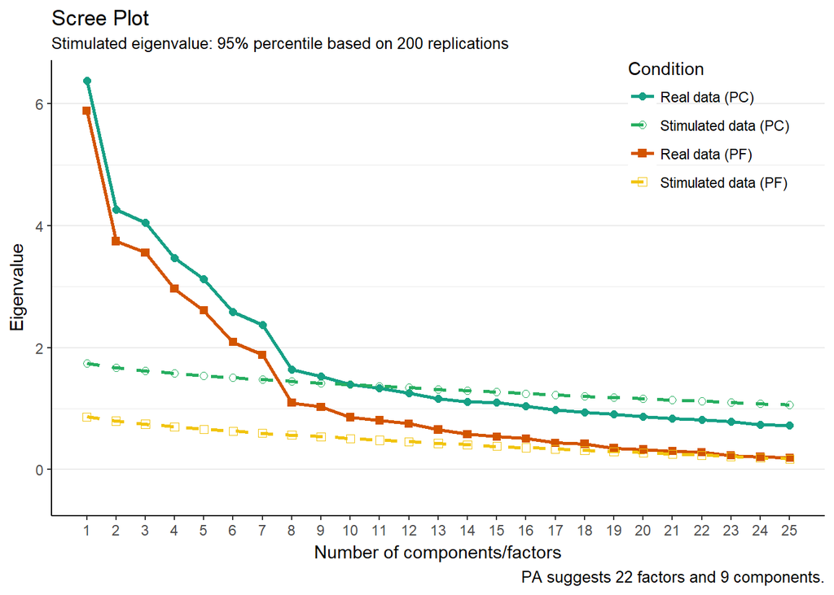

```r
psych.pa = function(PA, rep, baseline, maxfactor){

if (!require("pacman")) install.packages("pacman"); library(pacman)
  p_load(reshape2, ggplot2)


PA_df = data.frame(Root = 1:length(PA$pc.values), Real.pc = PA$pc.values, Sti.pc = PA$pc.sim,
                   Real.pf = PA$fa.values, Sti.pf = PA$fa.sim)
colnames(PA_df) = c("Root", "Real data (PC)", "Stimulated data (PC)", "Real data (PF)", "Stimulated data (PF)")

PA_df = melt(PA_df, id.vars = c("Root"),
             measure.vars = colnames(PA_df)[-1],
             variable.name="Condition",
             value.name="Eigenvalue")

ggplot(PA_df, aes(x=Root, y=Eigenvalue, color = Condition)) +
  geom_line(aes(y=Eigenvalue, colour = Condition, linetype = Condition), stat = 'identity', size = 1) +
  geom_point(aes(y=Eigenvalue, colour = Condition, shape = Condition), size = 2) +
  labs(x="Number of components/factors",y = "Eigenvalue", title = "Scree Plot",
       subtitle = paste0("Stimulated eigenvalue: ", as.character(baseline), "% percentile based on ", as.character(rep), " replications" ),
       caption = paste0("PA suggests ", as.character(PA$nfact), " factors and ", as.character(PA$ncomp), " components.")) +
  theme_bw() +
  scale_x_continuous(limits = c(1, maxfactor), breaks = rep(1:maxfactor)) +
  scale_color_manual(values=c("#16a085", "#27ae60", "#d35400", "#f1c40f")) +
  scale_linetype_manual(values=c("solid", "dashed", "solid", "dashed")) +
  scale_shape_manual(values=c(19, 1, 15, 0)) +
  theme(axis.line = element_line(colour = "black"), # Make "l" type axis
        panel.border = element_blank(), # Make "L" type axis
        legend.position=c(.85, .85), # Position of the legend
        legend.background = element_rect(fill = "transparent", size = .5, linetype = "dotted"),
        panel.grid.major.x = element_blank(), # Suppress major vertical gridlines
        panel.grid.minor.x = element_blank(), # Suppress minor vertical gridlines
        panel.background = element_rect(fill = "transparent", colour = NA), # Background transparent
        plot.background = element_rect(fill = "transparent", colour = NA)) # Background transparent

}

psych.pa(PA_poly, rep, baseline, 25)
```